# SDS 192: Homework #1

Sabrina Sayasith

Due: 2/1/16

> Instructions: This is a warm-up assignment designed to give you some familiarity working in `R`. If have been seen `R` before, these problems should not be very hard or take very long. If you have not seen `R` before, these problems will give you some practice and help to develop your skills. The content should not be difficult.

> This assignment, like all assignments that you complete in this course, is prepared in [R Markdown](http://rmarkdown.rstudio.com/): a markup language that allows you to easily format your code for readability and reproducibility. For more information about formatting in R Markdown, click on the question mark button in the menu bar of your Markdown document in [RStudio](http://www.rstudio.org), or read the [online documentation](http://rmarkdown.rstudio.com/authoring_basics.html). The benefit of using R Markdown is that it enables you to seamlessly combine `R` commands, the output from those commands, and written analysis into one document.

> You should submit this assignment on Moodle as an HTML file. That is, you should upload the rendered version of your Markdown document (it will have the file extension .html) to Moodle. **Please make sure that your Markdown document compiles before uploading!**

### Introduction and Review

Functionality in `R` comes from various packages that do various things. Loading packages is an important first step in the vast majority of cases.

You can load packages using the `require` command. One commonly-used package is **mosaic**. Make sure to include the `message=FALSE` option in the chunk that loads **mosaic**. This will suppress unwanted messages and keep your Markdown document neat and clean.

```r
require(mosaic)
```

Note that R is case-sensitive. That means capitalization counts. Like any programming language, spelling counts too. If you are unable to load the `mosaic` package using the preceding command, make sure that it is installed in your librarys. Click on the `Packages` tab in the lower right-hand corner of RStudio, and make sure you see `mosaic` listed. If not, click on `Install`.

Let’s start by loading some data. There are many data sets built into `R`, but in this case we’ll use something else. The **Galton** data set is part of the `mosaicData` package, and contains data on the height of many British adults, as well as the height of their mothers and fathers. To load it, we use the `data` command.

```r
require(mosaicData)
data(Galton)
```

**Galton** is now in our workspace as a `data.frame`. This is the basic data structure that we will work with most often. There are several options for figuring out what is in the `Galton` data frame. The easiest way is to click on the name of it in the Workspace tab.

> Note that clicking on the name of the data set in the Workspace tab will allow you to view it like a spreadsheet. This is fine for small data sets, but is not a good option for large ones!

But we can also ask `R` to tell us:

```r
# Will bring up the documentation in the Help window
help(Galton)
```

```
## starting httpd help server ...
```

```
##  done
```

```r
# What type of object is it?
class(Galton)
```

```
## [1] "data.frame"
```

```r
# What are its dimensions?
dim(Galton)
```

```
## [1] 898   6
```

```r
# How many rows and columns?
nrow(Galton)
```

```
## [1] 898
```

```r
ncol(Galton)
```

```
## [1] 6
```

```r
# What variables are present?
names(Galton)
```

```
## [1] "family" "father" "mother" "sex"    "height" "nkids"
```

```r
# A brief summary of each variable
summary(Galton)
```

```
##      family        father          mother      sex         height
##  185    : 15   Min.   :62.00   Min.   :58.00   F:433   Min.   :56.00
##  166    : 11   1st Qu.:68.00   1st Qu.:63.00   M:465   1st Qu.:64.00
##  66     : 11   Median :69.00   Median :64.00           Median :66.50
##  130    : 10   Mean   :69.23   Mean   :64.08           Mean   :66.76
##  136    : 10   3rd Qu.:71.00   3rd Qu.:65.50           3rd Qu.:69.70
##  140    : 10   Max.   :78.50   Max.   :70.50           Max.   :79.00
##  (Other):831
##      nkids
##  Min.   : 1.000
##  1st Qu.: 4.000
##  Median : 6.000
##  Mean   : 6.136
##  3rd Qu.: 8.000
##  Max.   :15.000
##
```

```r
# A look at the structure of the data.frame
str(Galton)
```

```
## 'data.frame':    898 obs. of  6 variables:
##  $ family: Factor w/ 197 levels "1","10","100",..: 1 1 1 1 108 108 108 108 123 123 ...
##  $ father: num  78.5 78.5 78.5 78.5 75.5 75.5 75.5 75.5 75 75 ...
##  $ mother: num  67 67 67 67 66.5 66.5 66.5 66.5 64 64 ...
##  $ sex   : Factor w/ 2 levels "F","M": 2 1 1 1 2 2 1 1 2 1 ...
##  $ height: num  73.2 69.2 69 69 73.5 72.5 65.5 65.5 71 68 ...
##  $ nkids : int  4 4 4 4 4 4 4 4 2 2 ...
```

```r
# A sample of the first few rows
head(Galton)
```

```
##   family father mother sex height nkids
## 1      1   78.5   67.0   M   73.2     4
## 2      1   78.5   67.0   F   69.2     4
## 3      1   78.5   67.0   F   69.0     4
## 4      1   78.5   67.0   F   69.0     4
## 5      2   75.5   66.5   M   73.5     4
## 6      2   75.5   66.5   M   72.5     4
```

#### Univariate Analysis

We will use the `formula` interface whenever possible. This means using the ~ (tilde) operator. To get a basic summary of a variable, use `favstats()`.

```r
favstats(~height, data = Galton)
```

```
##  min Q1 median   Q3 max     mean       sd   n missing
##   56 64   66.5 69.7  79 66.76069 3.582918 898       0
```

To specifically retrieve the mean or standard deviation, use the respective commands.

```r
mean(~height, data = Galton)
```

```
## [1] 66.76069
```

```r
sd(~height, data = Galton)
```

```
## [1] 3.582918
```

You can store these values to new variables if you want to use them later on.

> Note that while both the assignment operator (`<-`) and the equal sign (`=`) do the same thing, we prefer the former for clarity.

```r
mu <- mean(~height, data = Galton)
mu
```

```
## [1] 66.76069
```

For a graphical description of the distribution of a single variable, we can create a histogram or a density plot.

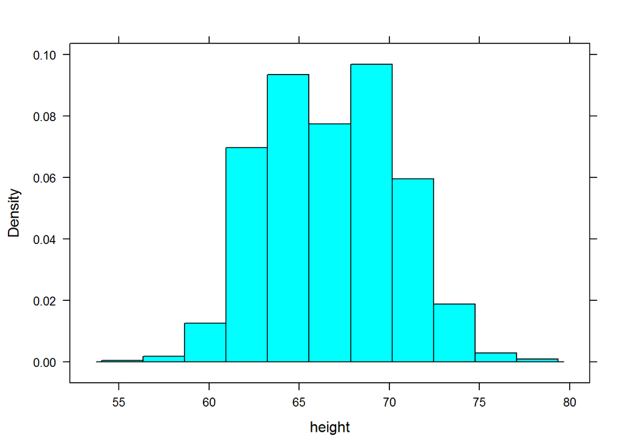

```r
histogram(~height, data = Galton)
```

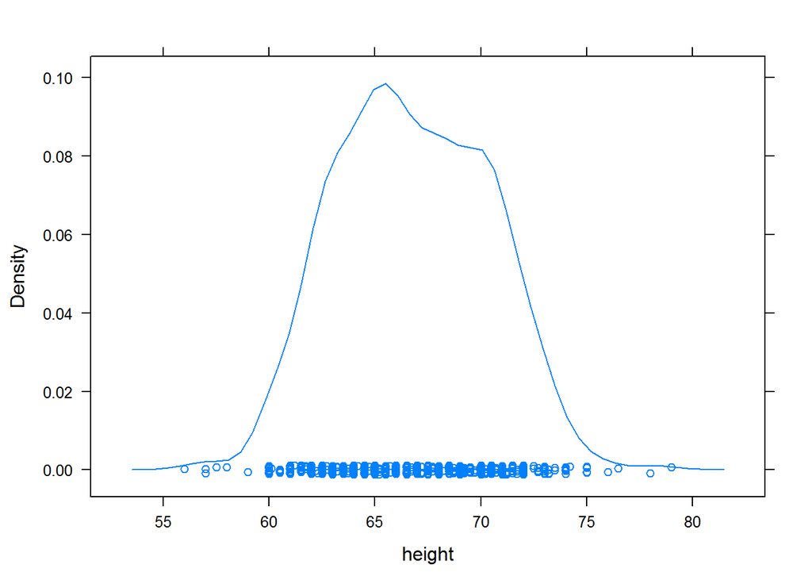

```r
densityplot(~height, data = Galton)
```

#### Bivariate Analysis

For assessing the relationship bewteen two variables, we can draw a scatterplot.

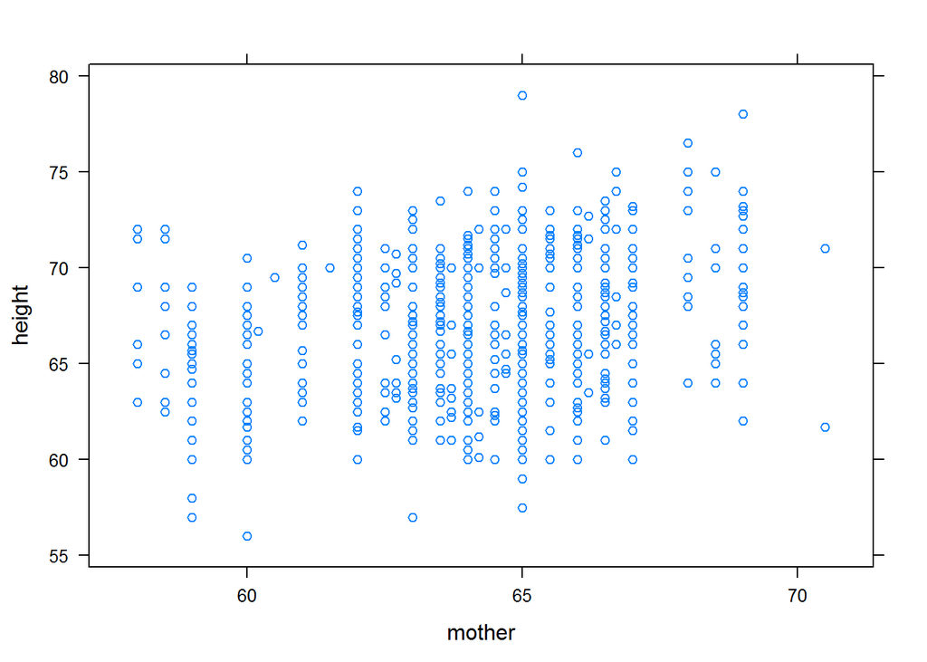

```r
xyplot(height ~ mother, data = Galton)
```

Note that there are many graphical options that we can add to this plot. Here is the same basic plot, but jazzed up a bit. You should experiment with graphical options! If you don’t know what is available, hit the tab key inside the function call. Or type `help(xyplot)`.

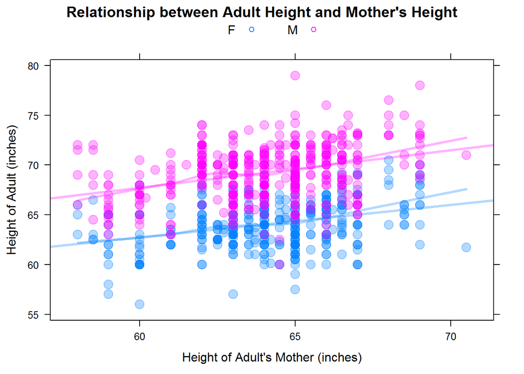

```r
xyplot(height ~ mother, groups = sex, data = Galton,
       type=c("p", "r", "smooth"),
       auto.key = list(columns = 2),
       pch = 19, alpha = 0.3, cex=1.5, lwd = 3,
       main="Relationship between Adult Height and Mother's Height",
       ylab="Height of Adult (inches)",
       xlab="Height of Adult's Mother (inches)")
```

Note that in this case we have conditioned on a third variable `sex`, by adding the `groups` argument.

For a numerical assessment of the linear relationship between two quantitative variables, we can compute their correlation coefficient.

```r
cor(height ~ mother, data = Galton)
```

```
## [1] 0.2016549
```

For relating a quantitative variable to a categorical variable, we can draw a box-and-whisker plot.

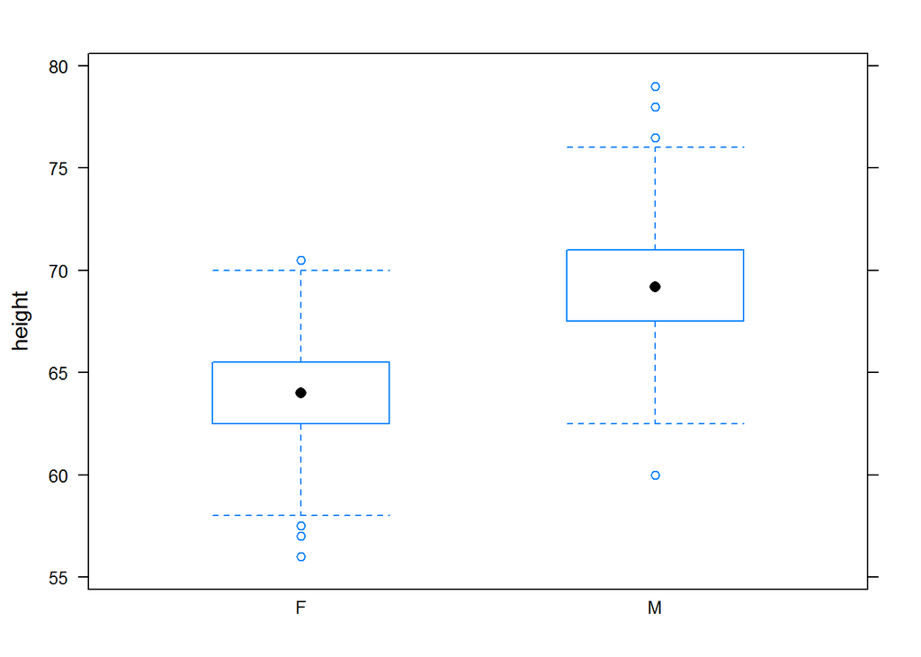

```r
bwplot(height ~ sex, data = Galton)
```

A table can also be useful here.

```r
favstats(height ~ sex, data = Galton)
```

```
##   sex min   Q1 median   Q3  max     mean       sd   n missing
## 1   F  56 62.5   64.0 65.5 70.5 64.11016 2.370320 433       0
## 2   M  60 67.5   69.2 71.0 79.0 69.22882 2.631594 465       0
```

Finally, for counting the frequency of categorical variables, you can use `tally()`.

```r
tally(~ sex + nkids, data = Galton)
```

```
##    nkids
## sex  1  2  3  4  5  6  7  8  9 10 11 15
##   F 15 18 31 48 61 57 61 61 32 24 17  8
##   M 17 22 35 68 79 57 51 67 31 16 15  7
```

### Exercises

These problems with use the `KidsFeet` data set, which is also part of `mosaicData`.

```r
data(KidsFeet)
```

A correct answer to each question consists of an R command that answers the question.

#### Problem 1

Let’s take a quick look at the first few rows of the data to see how it is organized.

```r
head(KidsFeet)
```

```
##     name birthmonth birthyear length width sex biggerfoot domhand
## 1  David          5        88   24.4   8.4   B          L       R
## 2   Lars         10        87   25.4   8.8   B          L       L
## 3   Zach         12        87   24.5   9.7   B          R       R
## 4   Josh          1        88   25.2   9.8   B          L       R
## 5   Lang          2        88   25.1   8.9   B          L       R
## 6 Scotty          3        88   25.7   9.7   B          R       R
```

And general background on the data:

```r
help(KidsFeet)
```

1. How many children are present in the data set?

Each child is represented by a row. So we use the command nrow to get the number of rows.

```r
nrow(KidsFeet)
```

```
## [1] 39
```

There are 39 kids present in the data.

2. What is the mean foot length?

We use the mean command to get the mean of a specific variable. length is the name of the variable describing foot length.

```r
mean(~length, data = KidsFeet)
```

```
## [1] 24.72308
```

The mean foot length is 24.72308 cm.

3. For how many children is their left foot bigger than their right?

We can use summary to get the number of entries marked ‘L’ under the variable ‘biggerfoot’.

```r
summary(KidsFeet)
```

```
##       name      birthmonth       birthyear         length
##  Caitlin: 2   Min.   : 1.000   Min.   :87.00   Min.   :21.60
##  David  : 2   1st Qu.: 3.000   1st Qu.:88.00   1st Qu.:24.00
##  Josh   : 2   Median : 6.000   Median :88.00   Median :24.50
##  Abby   : 1   Mean   : 6.103   Mean   :87.82   Mean   :24.72
##  Alisha : 1   3rd Qu.: 9.000   3rd Qu.:88.00   3rd Qu.:25.60
##  Andy   : 1   Max.   :12.000   Max.   :88.00   Max.   :27.50
##  (Other):30
##      width       sex    biggerfoot domhand
##  Min.   :7.900   B:20   L:22       L: 8
##  1st Qu.:8.650   G:19   R:17       R:31
##  Median :9.000
##  Mean   :8.992
##  3rd Qu.:9.350
##  Max.   :9.800
##
```

There are 22 children with their left foot bigger than their right.

4. What percentage of the children were left-handed?

We have 8 children who are left-handed and 31 who are right-handed from our summary in part c. We can do a simple calculation to get the percentage.

```r
(8/(31+8))*100
```

```
## [1] 20.51282
```

20.51282% of children are left-handed.

5. Which month contained the most births?

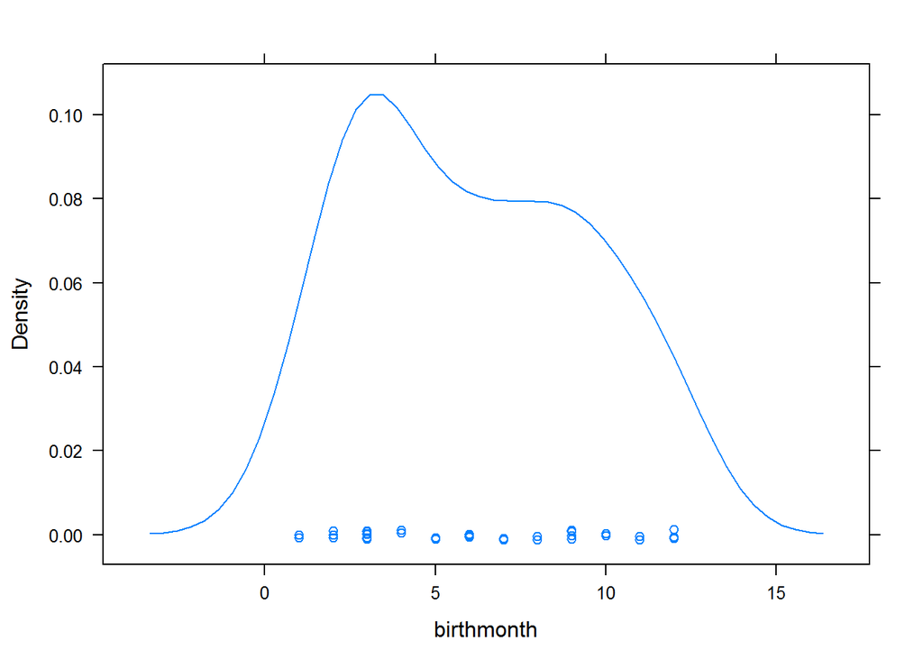

```r
densityplot(~birthmonth, data = KidsFeet)
```

```r
tally(~birthmonth, data = KidsFeet)
```

```
##
##  1  2  3  4  5  6  7  8  9 10 11 12
##  2  3  8  3  2  4  3  2  5  2  2  3
```

Month 3, March, contained 8 births, the most births compared to the other months.

6. Were boys’ feet longer, on average, than girls’? If so, by how much?

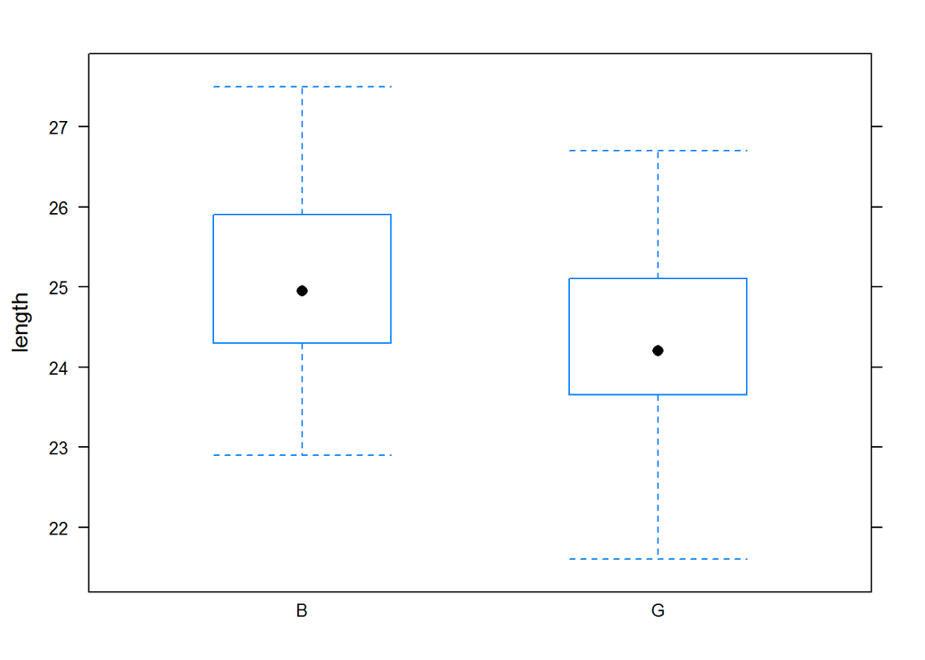

```r
bwplot(length ~ sex, data = KidsFeet)
```

```r
favstats(length ~ sex, data = KidsFeet)
```

```
##   sex  min    Q1 median   Q3  max     mean       sd  n missing
## 1   B 22.9 24.35  24.95 25.8 27.5 25.10500 1.216758 20       0
## 2   G 21.6 23.65  24.20 25.1 26.7 24.32105 1.330238 19       0
```

```r
25.10500 - 24.32105
```

```
## [1] 0.78395
```

Boys’ feet were longer, on average, shown by the box plot. Using favstats, we get the average length for boys and the average length for girls. Boys’ feet were longer that girls by 0.78395 cm on average.

7. Were left-handed kids more or less likely to have a bigger left foot?

```r
tally(~ biggerfoot + domhand, data = KidsFeet)
```

```
##           domhand
## biggerfoot  L  R
##          L  2 20
##          R  6 11
```

#### Problem 2

1. Draw a scatterplot of foot length as a function of foot width. Put the least squares regression line on the plot and provide meaningful axis labels.

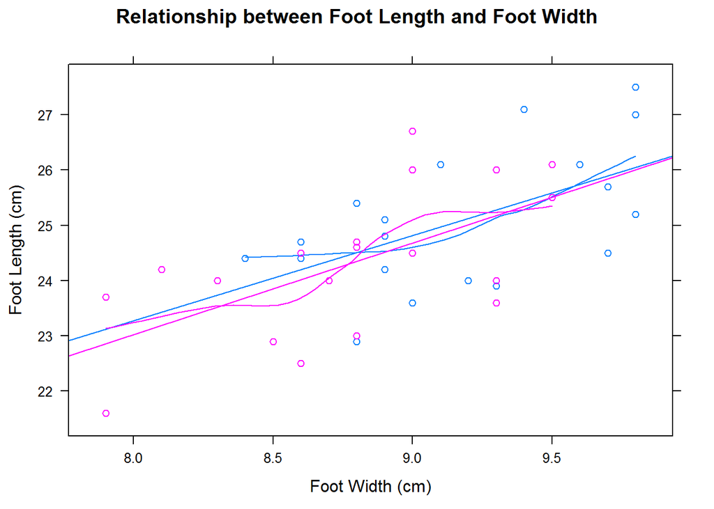

```r
xyplot(length ~ width, groups = sex, data = KidsFeet,
       type=c("p", "r", "smooth"),
       main="Relationship between Foot Length and Foot Width",
       ylab="Foot Length (cm)",
       xlab="Foot Width (cm)")
```

2. What is the correlation between foot length and foot width?

```r
cor(length ~ width, data = KidsFeet)
```

```
## [1] 0.6410961
```

0.6410961 is the correlation.

3. Do you find evidence that gender plays a signficant role in determining the length of a child’s foot, after taking into account the width of that child’s foot? Defend your answer with statistical or graphical evidence.

We found in part a and b of question 2 that there is a positive correlation between foot length and foot width. We need to determine if overall boy have larger foot lengths than girls with the same. We see that the regression lines from question 2 part a answers this for us. We see that the regression line for boys is higher than that of girls up until they converge at the upper limits of foot width. Thus, overall, boys will have a longer foot length after taking into account the width of the child’s foot.